# Tugas Individu Pertemuan 3 - Regresi dengan Peubah Lag

Studi Kasus: Indeks Kualitas Udara (AQI) Kota New Delhi

reva yulita sari - x1004261008

09 September 2026

# 1 Pendahuluan

Tugas ini menerapkan tiga metode regresi dengan peubah lag – **Koyck**, **Distributed Lag Model (DLM)**, dan **Autoregressive Distributed Lag (ARDL)** – pada data kualitas udara per jam Kota New Delhi. Peubah dependen ($Y$) yang digunakan adalah **AQI (Air Quality Index)**, sedangkan peubah independen ($X$) dipilih dari salah satu polutan yang tersedia (CO, NO2, O3, PM10, PM2.5, atau SO2).

# 2 *Packages*

```r
#PACKAGES
library(dLagM)
library(dynlm)
library(MLmetrics)
library(lmtest)
library(car)
```

# 3 Impor dan Eksplorasi Data

```r
#IMPOR DATA
data <- read.csv("C:/Users/USER/Downloads/NewDelhi_Air_quality.csv")
data <- data[order(data$ts), ]   # urutkan berdasarkan waktu
str(data)
```

```
## 'data.frame':    72 obs. of  12 variables:
##  $ X              : int  0 1 2 3 4 5 6 7 8 9 ...
##  $ AQI            : num  30.2 28.2 26.6 25 26 26 26 24 23 24 ...
##  $ CO             : num  199 198 199 202 205 ...
##  $ datetime       : chr  "2022-10-21:18" "2022-10-21:19" "2022-10-21:20" "2022-10-21:21" ...
##  $ no2            : num  0.0469 0.0465 0.0469 0.0482 0.0489 ...
##  $ o3             : num  55.8 54.9 54.6 55.1 55.8 ...
##  $ pm10           : num  10.5 10.7 11.2 11.1 10.4 ...
##  $ pm25           : num  5.64 4.62 3.52 2.23 1.98 ...
##  $ so2            : num  0.387 0.41 0.402 0.376 0.339 ...
##  $ timestamp_local: chr  "2022-10-21T23:00:00" "2022-10-22T00:00:00" "2022-10-22T01:00:00" "2022-10-22T02:00:00" ...
##  $ timestamp_utc  : chr  "2022-10-21T18:00:00" "2022-10-21T19:00:00" "2022-10-21T20:00:00" "2022-10-21T21:00:00" ...
##  $ ts             : int  1666375200 1666378800 1666382400 1666386000 1666389600 1666393200 1666396800 1666400400 1666404000 1666407600 ...
```

```r
head(data)
```

|  | X | AQI | CO | datetime | no2 | o3 | pm10 | pm25 | so2 | timestamp_local | timestamp_utc | ts |
| --- | --- | --- | --- | --- | --- | --- | --- | --- | --- | --- | --- | --- |
| 1 | 0 | 30.2 | 198.6027 | 2022-10-21:18 | 0.04685717 | 55.78995 | 10.486722 | 5.637410 | 0.3874302 | 2022-10-21T23:00:00 | 2022-10-21T18:00:00 | 1666375200 |
| 2 | 1 | 28.2 | 197.6013 | 2022-10-21:19 | 0.04645554 | 54.93164 | 10.719325 | 4.618169 | 0.4097819 | 2022-10-22T00:00:00 | 2022-10-21T19:00:00 | 1666378800 |
| 3 | 2 | 26.6 | 198.6027 | 2022-10-21:20 | 0.04685717 | 54.64554 | 11.155578 | 3.520902 | 0.4023313 | 2022-10-22T01:00:00 | 2022-10-21T20:00:00 | 1666382400 |
| 4 | 3 | 25.0 | 201.9405 | 2022-10-21:21 | 0.04819594 | 55.07469 | 11.116206 | 2.225919 | 0.3762543 | 2022-10-22T02:00:00 | 2022-10-21T21:00:00 | 1666386000 |
| 5 | 4 | 26.0 | 205.2784 | 2022-10-21:22 | 0.04886533 | 55.78995 | 10.405250 | 1.979471 | 0.3390014 | 2022-10-22T03:00:00 | 2022-10-21T22:00:00 | 1666389600 |
| 6 | 5 | 26.0 | 208.6163 | 2022-10-21:23 | 0.05020411 | 56.50520 | 9.402518 | 1.792677 | 0.3129244 | 2022-10-22T04:00:00 | 2022-10-21T23:00:00 | 1666393200 |

Data terdiri atas **72 observasi per jam** dengan peubah AQI dan enam polutan (CO, NO2, O3, PM10, PM2.5, SO2).

## 3.1 Pemilihan Peubah Independen (X)

Pemilihan peubah $X$ dilakukan dengan melihat korelasi Pearson masing-masing polutan terhadap AQI. Polutan dengan korelasi absolut tertinggi dipilih sebagai peubah independen.

```r
polutan <- c("CO","no2","o3","pm10","pm25","so2")
korelasi <- sapply(data[, polutan], function(x) cor(data$AQI, x))
sort(round(korelasi, 4), decreasing = TRUE)
```

```
##      o3      CO     no2    pm10    pm25     so2
##  0.9736  0.7976  0.7377  0.0826 -0.3467 -0.7425
```

Berdasarkan hasil di atas, peubah **O3 (Ozon)** memiliki korelasi paling kuat terhadap AQI (sekitar **0.97**), sehingga peubah tersebut dipilih sebagai peubah independen $X$. Peubah $Y$ tetap AQI.

```r
df <- data.frame(Yt = data$AQI, Xt = data$o3)
head(df)
```

|  | Yt | Xt |
| --- | --- | --- |
| 1 | 30.2 | 55.78995 |
| 2 | 28.2 | 54.93164 |
| 3 | 26.6 | 54.64554 |
| 4 | 25.0 | 55.07469 |
| 5 | 26.0 | 55.78995 |
| 6 | 26.0 | 56.50520 |

# 4 Pembagian Data

Data dibagi menjadi data latih (80%) dan data uji (20%) secara berurutan (tanpa acak) karena data bersifat deret waktu.

```r
#SPLIT DATA
n <- nrow(df)
n_train <- floor(0.8 * n)

train <- df[1:n_train, ]
test  <- df[(n_train + 1):n, ]

cat("Jumlah data latih :", nrow(train), "\n")
```

```
## Jumlah data latih : 57
```

```r
cat("Jumlah data uji    :", nrow(test), "\n")
```

```
## Jumlah data uji    : 15
```

```r
#data time series
train.ts <- ts(train)
test.ts  <- ts(test)
data.ts  <- ts(df)
```

- **Distributed Lag Model** : Peubah dependen $Y$ dipengaruhi oleh lag dari peubah independen $X$ ($X_{t-1}, X_{t-2}, ...$)
- **Autoregressive Model** : Peubah dependen $Y$ dipengaruhi oleh lag dirinya sendiri ($Y_{t-1}, Y_{t-2}, ...$) dan $X$ pada waktu sekarang ($X_t$)

# 5 Model Koyck

Model Koyck mengasumsikan bahwa semakin jauh jarak lag peubah independen dari periode sekarang, semakin kecil pengaruhnya terhadap peubah dependen (geometric lag).

$$y_t=a(1-\lambda)+\beta_0X_t+\lambda Y_{t-1}+V_t$$

## 5.1 Pemodelan

```r
#MODEL KOYCK
model.koyck <- koyckDlm(x = train$Xt, y = train$Yt)
summary(model.koyck)
```

```
##
## Call:
## "Y ~ (Intercept) + Y.1 + X.t"
##
## Residuals:
##       Min        1Q    Median        3Q       Max
## -1.127670 -0.301407  0.001002  0.262601  1.103471
##
## Coefficients:
##             Estimate Std. Error t value Pr(>|t|)
## (Intercept)  0.54798    0.92878   0.590    0.558
## Y.1          0.41955    0.08223   5.102 4.63e-06 ***
## X.t          0.25830    0.04107   6.289 6.25e-08 ***
## ---
## Signif. codes:  0 '***' 0.001 '**' 0.01 '*' 0.05 '.' 0.1 ' ' 1
##
## Residual standard error: 0.5053 on 53 degrees of freedom
## Multiple R-Squared: 0.9463,  Adjusted R-squared: 0.9443
## Wald test: 423.7 on 2 and 53 DF,  p-value: < 2.2e-16
##
## Diagnostic tests:
## NULL
##
##                             alpha      beta       phi
## Geometric coefficients:  0.944071 0.2582957 0.4195528
```

```r
AIC(model.koyck)
```

```
## [1] 87.39413
```

```r
BIC(model.koyck)
```

```
## [1] 95.49554
```

Hasil di atas menunjukkan bahwa peubah $Y_{t-1}$ dan $X_t$ memiliki nilai $p$-value $<0.05$, artinya keduanya berpengaruh signifikan terhadap $Y_t$. Model yang terbentuk adalah:

$$\hat{Y_t}=0.5480+0.2583X_t+0.4196Y_{t-1}$$

## 5.2 Peramalan dan Akurasi

```r
fore.koyck <- forecast(model = model.koyck, x = test$Xt, h = nrow(test))
fore.koyck
```

```
## $forecasts
##  [1] 24.15387 23.05989 21.95429 21.12094 20.21706 19.74546 20.00947 20.67448
##  [9] 20.95348 21.07054 21.58152 23.08914 24.83015 26.29958 27.28558
##
## $call
## forecast.koyckDlm(model = model.koyck, x = test$Xt, h = nrow(test))
##
## attr(,"class")
## [1] "forecast.koyckDlm" "dLagM"
```

```r
mape.koyck <- MLmetrics::MAPE(fore.koyck$forecasts, test$Yt)
mape.koyck  #akurasi data uji
```

```
## [1] 0.03187326
```

```r
GoF(model.koyck)  #akurasi data latih
```

|  | n | MAE | MPE | MAPE | sMAPE | MASE | MSE | MRAE | GMRAE |
| --- | --- | --- | --- | --- | --- | --- | --- | --- | --- |
| model.koyck | 56 | 0.3849916 | -0.00049635 | 0.01435646 | 0.01433475 | 0.6015494 | 0.2416839 | 589435374 | 7663.933 |

Model Koyck menghasilkan MAPE data uji sebesar **3.19%**, yang tergolong sangat baik (< 10%).

# 6 Regression with Distributed Lag (DLM)

## 6.1 Pemodelan (Lag = 1)

```r
model.dlm <- dlm(x = train$Xt, y = train$Yt, q = 1)
summary(model.dlm)
```

```
##
## Call:
## lm(formula = model.formula, data = design)
##
## Residuals:
##      Min       1Q   Median       3Q      Max
## -0.51031 -0.40204 -0.09081  0.21207  2.78493
##
## Coefficients:
##             Estimate Std. Error t value Pr(>|t|)
## (Intercept)  0.46584    0.91660   0.508    0.613
## x.t          0.46014    0.04655   9.886 1.26e-13 ***
## x.1         -0.00586    0.04676  -0.125    0.901
## ---
## Signif. codes:  0 '***' 0.001 '**' 0.01 '*' 0.05 '.' 0.1 ' ' 1
##
## Residual standard error: 0.519 on 53 degrees of freedom
## Multiple R-squared:  0.9434, Adjusted R-squared:  0.9413
## F-statistic: 441.6 on 2 and 53 DF,  p-value: < 2.2e-16
##
## AIC and BIC values for the model:
##        AIC      BIC
## 1 90.38861 98.49001
```

```r
AIC(model.dlm)
```

```
## [1] 90.38861
```

```r
BIC(model.dlm)
```

```
## [1] 98.49001
```

Pada model dengan $q=1$, hanya $X_t$ yang signifikan ($p<0.05$), sedangkan $X_{t-1}$ tidak signifikan. Model yang terbentuk:

$$\hat{Y_t}=0.4658+0.4601X_t-0.0059X_{t-1}$$

### 6.1.1 Peramalan dan Akurasi

```r
fore.dlm <- forecast(model = model.dlm, x = test$Xt, h = nrow(test))
fore.dlm
```

```
## $forecasts
##  [1] 23.51458 22.21907 21.08393 20.44036 19.46140 19.30941 20.13430 21.11117
##  [9] 21.09860 21.09860 21.92139 24.21473 26.16009 27.45140 28.09287
##
## $call
## forecast.dlm(model = model.dlm, x = test$Xt, h = nrow(test))
##
## attr(,"class")
## [1] "forecast.dlm" "dLagM"
```

```r
mape.dlm <- MLmetrics::MAPE(fore.dlm$forecasts, test$Yt)
mape.dlm
```

```
## [1] 0.01060177
```

```r
GoF(model.dlm)
```

|  | n | MAE | MPE | MAPE | sMAPE | MASE | MSE | MRAE | GMRAE |
| --- | --- | --- | --- | --- | --- | --- | --- | --- | --- |
| model.dlm | 56 | 0.3262127 | -0.0003478803 | 0.01204651 | 0.0121276 | 0.5097073 | 0.2549592 | 1040131039 | 6923.684 |

## 6.2 *Lag* Optimum DLM

```r
#penentuan lag optimum
finiteDLMauto(formula = Yt ~ Xt,
              data = data.frame(train), q.min = 1, q.max = 10,
              model.type = "dlm", error.type = "AIC", trace = TRUE)
```

|  | q - k | MASE | AIC | BIC | GMRAE | MBRAE | R.Adj.Sq | Ljung-Box |
| --- | --- | --- | --- | --- | --- | --- | --- | --- |
| 10 | 10 | 0.35051 | 22.97129 | 47.02321 | 14499.820 | 0.49589 | 0.98302 | 0.35474502 |
| 3 | 3 | 0.39875 | 27.06744 | 39.00134 | 6447.089 | 0.49480 | 0.98198 | 0.10728965 |
| 5 | 5 | 0.38245 | 27.17252 | 42.78247 | 7468.898 | 0.49506 | 0.98252 | 0.17930776 |
| 4 | 4 | 0.39892 | 27.90158 | 41.69362 | 8742.382 | 0.49838 | 0.98187 | 0.16589034 |
| 9 | 9 | 0.38342 | 29.59952 | 52.05393 | 11575.966 | 0.50164 | 0.98105 | 0.83879203 |
| 6 | 6 | 0.38046 | 29.81810 | 47.20453 | 6019.920 | 0.48473 | 0.98200 | 0.19113496 |
| 7 | 7 | 0.39444 | 30.91101 | 50.03124 | 7435.980 | 0.49025 | 0.98199 | 0.27024407 |
| 8 | 8 | 0.40121 | 31.26668 | 52.07671 | 10182.702 | 0.51165 | 0.98151 | 0.41738843 |
| 2 | 2 | 0.42869 | 46.47280 | 56.50947 | 6714.446 | 0.48891 | 0.97365 | 0.08751929 |
| 1 | 1 | 0.50971 | 90.38861 | 98.49001 | 6923.684 | 0.40817 | 0.94126 | 0.16081431 |

Berdasarkan kriteria AIC, lag optimum tercapai pada **q = 10** (AIC terendah $\approx$ 22.97). Selanjutnya dilakukan pemodelan dengan $q=10$.

```r
model.dlm2 <- dlm(x = train$Xt, y = train$Yt, q = 10)
summary(model.dlm2)
```

```
##
## Call:
## lm(formula = model.formula, data = design)
##
## Residuals:
##     Min      1Q  Median      3Q     Max
## -0.5204 -0.1663  0.0356  0.1624  0.5130
##
## Coefficients:
##              Estimate Std. Error t value Pr(>|t|)
## (Intercept) -0.294780   0.931786  -0.316  0.75361
## x.t          0.405638   0.063702   6.368 2.54e-07 ***
## x.1          0.159000   0.133129   1.194  0.24038
## x.2         -0.052741   0.126788  -0.416  0.67997
## x.3         -0.148621   0.121282  -1.225  0.22860
## x.4          0.143544   0.124404   1.154  0.25638
## x.5         -0.007047   0.123348  -0.057  0.95476
## x.6         -0.127683   0.123191  -1.036  0.30709
## x.7          0.287823   0.121937   2.360  0.02396 *
## x.8         -0.399437   0.121443  -3.289  0.00230 **
## x.9          0.304147   0.103813   2.930  0.00594 **
## x.10        -0.098958   0.048025  -2.061  0.04684 *
## ---
## Signif. codes:  0 '***' 0.001 '**' 0.01 '*' 0.05 '.' 0.1 ' ' 1
##
## Residual standard error: 0.2715 on 35 degrees of freedom
## Multiple R-squared:  0.9871, Adjusted R-squared:  0.983
## F-statistic: 243.1 on 11 and 35 DF,  p-value: < 2.2e-16
##
## AIC and BIC values for the model:
##        AIC      BIC
## 1 22.97129 47.02321
```

```r
AIC(model.dlm2)
```

```
## [1] 22.97129
```

```r
BIC(model.dlm2)
```

```
## [1] 47.02321
```

Pada model dengan lag optimum ($q=10$), peubah yang signifikan pada taraf nyata 5% antara lain $X_t$, $X_{t-7}$, $X_{t-8}$, $X_{t-9}$, dan $X_{t-10}$.

### 6.2.1 Peramalan dan Akurasi

```r
fore.dlm2 <- forecast(model = model.dlm2, x = test$Xt, h = nrow(test))
mape.dlm2 <- MLmetrics::MAPE(fore.dlm2$forecasts, test$Yt)
mape.dlm2
```

```
## [1] 0.01274404
```

```r
GoF(model.dlm2)
```

|  | n | MAE | MPE | MAPE | sMAPE | MASE | MSE | MRAE | GMRAE |
| --- | --- | --- | --- | --- | --- | --- | --- | --- | --- |
| model.dlm2 | 47 | 0.198112 | -6.467038e-05 | 0.007238929 | 0.007234284 | 0.3505059 | 0.05489584 | 894254642 | 14499.82 |

# 7 Model Autoregressive Distributed Lag (ARDL)

Model ARDL berordo $(p,q)$ melibatkan lag dari peubah independen ($p$) sekaligus lag dari peubah dependen itu sendiri ($q$).

## 7.1 Pemodelan ARDL(1,1)

```r
model.ardl <- ardlDlm(formula = Yt ~ Xt, data = train, p = 1, q = 1)
summary(model.ardl)
```

```
##
## Time series regression with "ts" data:
## Start = 2, End = 57
##
## Call:
## dynlm(formula = as.formula(model.text), data = data)
##
## Residuals:
##     Min      1Q  Median      3Q     Max
## -1.0261 -0.2582  0.1254  0.2988  0.8683
##
## Coefficients:
##             Estimate Std. Error t value Pr(>|t|)
## (Intercept) -0.14906    0.67926  -0.219    0.827
## Xt.t         0.47821    0.03429  13.946  < 2e-16 ***
## Xt.1        -0.22331    0.04692  -4.759 1.59e-05 ***
## Yt.1         0.45264    0.06656   6.801 1.03e-08 ***
## ---
## Signif. codes:  0 '***' 0.001 '**' 0.01 '*' 0.05 '.' 0.1 ' ' 1
##
## Residual standard error: 0.3812 on 52 degrees of freedom
## Multiple R-squared:   0.97,  Adjusted R-squared:  0.9683
## F-statistic: 561.2 on 3 and 52 DF,  p-value: < 2.2e-16
```

```r
AIC(model.ardl)
```

```
## [1] 56.75817
```

```r
BIC(model.ardl)
```

```
## [1] 66.88493
```

Seluruh peubah ($X_t$, $X_{t-1}$, dan $Y_{t-1}$) signifikan pada taraf nyata 5%. Model yang terbentuk:

$$\hat{Y_t}=-0.1491+0.4782X_t-0.2233X_{t-1}+0.4526Y_{t-1}$$

### 7.1.1 Peramalan dan Akurasi

```r
fore.ardl <- forecast(model = model.ardl, x = test$Xt, h = nrow(test))
fore.ardl
```

```
## $forecasts
##  [1] 23.31352 21.98057 20.81893 20.16806 19.16675 19.02165 19.89095 20.91127
##  [9] 20.89394 20.88610 21.73767 24.11814 26.12988 27.45034 28.09325
##
## $call
## forecast.ardlDlm(model = model.ardl, x = test$Xt, h = nrow(test))
##
## attr(,"class")
## [1] "forecast.ardlDlm" "dLagM"
```

```r
mape.ardl <- MLmetrics::MAPE(fore.ardl$forecasts, test$Yt)
mape.ardl
```

```
## [1] 0.006897306
```

```r
GoF(model.ardl)
```

|  | n | MAE | MPE | MAPE | sMAPE | MASE | MSE | MRAE | GMRAE |
| --- | --- | --- | --- | --- | --- | --- | --- | --- | --- |
| model.ardl | 56 | 0.3133364 | -0.000175342 | 0.01160232 | 0.01159132 | 0.4895881 | 0.1349421 | 1111894888 | 8007.311 |

## 7.2 *Lag* / Orde Optimum ARDL

```r
model.ardl.opt <- ardlBoundOrders(data = data.frame(train), ic = "AIC",
                                   formula = Yt ~ Xt, max.p = 6, max.q = 6)
model.ardl.opt
```

```
## $p
##   Xt
## 1  2
##
## $q
## [1] 1
##
## $Stat.table
##          q = 1    q = 2    q = 3    q = 4    q = 5    q = 6
## p = 1 41.62720 26.97270 29.19019 31.33838 31.55993 32.30452
## p = 2 26.78053 28.78047 31.18861 32.82477 32.62688 32.48412
## p = 3 31.29643 31.29643 33.17310 34.82462 34.62505 31.83024
## p = 4 31.18772 32.66068 32.66068 31.38167 34.00491 33.82865
## p = 5 32.54160 33.56222 34.17049 34.17049 35.78014 35.44887
## p = 6 33.85448 35.23826 33.54028 35.45511 35.45511 37.44736
##
## $min.Stat
## [1] 26.78053
```

```r
model.ardl.opt$min.Stat
```

```
## [1] 26.78053
```

Nilai AIC terendah diperoleh pada kombinasi $p=2$ (lag $X$) dan $q=1$ (lag $Y$). Selanjutnya dilakukan pemodelan dengan orde optimum tersebut.

```r
model.ardl.opt.fit <- ardlDlm(formula = Yt ~ Xt, data = train, p = 2, q = 1)
summary(model.ardl.opt.fit)
```

```
##
## Time series regression with "ts" data:
## Start = 3, End = 57
##
## Call:
## dynlm(formula = as.formula(model.text), data = data)
##
## Residuals:
##      Min       1Q   Median       3Q      Max
## -0.65160 -0.34093  0.03943  0.29017  0.88957
##
## Coefficients:
##              Estimate Std. Error t value Pr(>|t|)
## (Intercept) -0.165874   0.671234  -0.247   0.8058
## Xt.t         0.480286   0.052213   9.199 2.47e-12 ***
## Xt.1        -0.097207   0.105825  -0.919   0.3627
## Xt.2        -0.004654   0.053756  -0.087   0.9314
## Yt.1         0.185468   0.089958   2.062   0.0445 *
## ---
## Signif. codes:  0 '***' 0.001 '**' 0.01 '*' 0.05 '.' 0.1 ' ' 1
##
## Residual standard error: 0.3394 on 50 degrees of freedom
## Multiple R-squared:  0.9771, Adjusted R-squared:  0.9752
## F-statistic: 532.4 on 4 and 50 DF,  p-value: < 2.2e-16
```

```r
AIC(model.ardl.opt.fit)
```

```
## [1] 43.98524
```

```r
BIC(model.ardl.opt.fit)
```

```
## [1] 56.02924
```

```r
fore.ardl.opt <- forecast(model = model.ardl.opt.fit, x = test$Xt, h = nrow(test))
mape.ardl.opt <- MLmetrics::MAPE(fore.ardl.opt$forecasts, test$Yt)
mape.ardl.opt
```

```
## [1] 0.006848092
```

```r
GoF(model.ardl.opt.fit)
```

|  | n | MAE | MPE | MAPE | sMAPE | MASE | MSE | MRAE | GMRAE |
| --- | --- | --- | --- | --- | --- | --- | --- | --- | --- |
| model.ardl.opt.fit | 55 | 0.2796051 | -0.0001350786 | 0.01036473 | 0.01036116 | 0.4493653 | 0.1047344 | 1057296286 | 8580.366 |

Model ARDL(2,1) memberikan AIC/BIC yang lebih baik dibanding ARDL(1,1) dan MAPE data uji yang sedikit lebih kecil.

# 8 Pemodelan DLM & ARDL dengan *Package* `dynlm`

Sebagai pembanding, pemodelan juga dilakukan menggunakan fungsi `dynlm()` untuk mempermudah pengujian asumsi klasik dan uji *encompassing*.

```r
#sama dengan model dlm q=1
cons_lm1 <- dynlm(Yt ~ Xt + L(Xt), data = train.ts)

#sama dengan model ardl p=0, q=1 (AR murni + Xt)
cons_lm2 <- dynlm(Yt ~ Xt + L(Yt), data = train.ts)

#sama dengan ardl p=1, q=1
cons_lm3 <- dynlm(Yt ~ Xt + L(Xt) + L(Yt), data = train.ts)

#sama dengan dlm q=2
cons_lm4 <- dynlm(Yt ~ Xt + L(Xt) + L(Xt,2), data = train.ts)
```

## 8.1 Ringkasan Model

```r
summary(cons_lm1)
```

```
##
## Time series regression with "ts" data:
## Start = 2, End = 57
##
## Call:
## dynlm(formula = Yt ~ Xt + L(Xt), data = train.ts)
##
## Residuals:
##      Min       1Q   Median       3Q      Max
## -0.51031 -0.40204 -0.09081  0.21207  2.78493
##
## Coefficients:
##             Estimate Std. Error t value Pr(>|t|)
## (Intercept)  0.46584    0.91660   0.508    0.613
## Xt           0.46014    0.04655   9.886 1.26e-13 ***
## L(Xt)       -0.00586    0.04676  -0.125    0.901
## ---
## Signif. codes:  0 '***' 0.001 '**' 0.01 '*' 0.05 '.' 0.1 ' ' 1
##
## Residual standard error: 0.519 on 53 degrees of freedom
## Multiple R-squared:  0.9434, Adjusted R-squared:  0.9413
## F-statistic: 441.6 on 2 and 53 DF,  p-value: < 2.2e-16
```

```r
summary(cons_lm2)
```

```
##
## Time series regression with "ts" data:
## Start = 2, End = 57
##
## Call:
## dynlm(formula = Yt ~ Xt + L(Yt), data = train.ts)
##
## Residuals:
##      Min       1Q   Median       3Q      Max
## -0.78961 -0.30739 -0.06053  0.20120  1.70996
##
## Coefficients:
##             Estimate Std. Error t value Pr(>|t|)
## (Intercept) -0.27989    0.80546  -0.347 0.729596
## Xt           0.35714    0.02728  13.091  < 2e-16 ***
## L(Yt)        0.23682    0.05781   4.096 0.000144 ***
## ---
## Signif. codes:  0 '***' 0.001 '**' 0.01 '*' 0.05 '.' 0.1 ' ' 1
##
## Residual standard error: 0.4524 on 53 degrees of freedom
## Multiple R-squared:  0.957,  Adjusted R-squared:  0.9554
## F-statistic: 589.6 on 2 and 53 DF,  p-value: < 2.2e-16
```

```r
summary(cons_lm3)
```

```
##
## Time series regression with "ts" data:
## Start = 2, End = 57
##
## Call:
## dynlm(formula = Yt ~ Xt + L(Xt) + L(Yt), data = train.ts)
##
## Residuals:
##     Min      1Q  Median      3Q     Max
## -1.0261 -0.2582  0.1254  0.2988  0.8683
##
## Coefficients:
##             Estimate Std. Error t value Pr(>|t|)
## (Intercept) -0.14906    0.67926  -0.219    0.827
## Xt           0.47821    0.03429  13.946  < 2e-16 ***
## L(Xt)       -0.22331    0.04692  -4.759 1.59e-05 ***
## L(Yt)        0.45264    0.06656   6.801 1.03e-08 ***
## ---
## Signif. codes:  0 '***' 0.001 '**' 0.01 '*' 0.05 '.' 0.1 ' ' 1
##
## Residual standard error: 0.3812 on 52 degrees of freedom
## Multiple R-squared:   0.97,  Adjusted R-squared:  0.9683
## F-statistic: 561.2 on 3 and 52 DF,  p-value: < 2.2e-16
```

```r
summary(cons_lm4)
```

```
##
## Time series regression with "ts" data:
## Start = 3, End = 57
##
## Call:
## dynlm(formula = Yt ~ Xt + L(Xt) + L(Xt, 2), data = train.ts)
##
## Residuals:
##      Min       1Q   Median       3Q      Max
## -0.45678 -0.35809 -0.02571  0.25176  1.40513
##
## Coefficients:
##              Estimate Std. Error t value Pr(>|t|)
## (Intercept) -0.052782   0.689979  -0.076    0.939
## Xt           0.476379   0.053816   8.852 6.95e-12 ***
## L(Xt)       -0.005756   0.099095  -0.058    0.954
## L(Xt, 2)    -0.008392   0.055411  -0.151    0.880
## ---
## Signif. codes:  0 '***' 0.001 '**' 0.01 '*' 0.05 '.' 0.1 ' ' 1
##
## Residual standard error: 0.3501 on 51 degrees of freedom
## Multiple R-squared:  0.9751, Adjusted R-squared:  0.9736
## F-statistic:   666 on 3 and 51 DF,  p-value: < 2.2e-16
```

## 8.2 *Deviance* (SSE)

```r
deviance(cons_lm1)
```

```
## [1] 14.27771
```

```r
deviance(cons_lm2)
```

```
## [1] 10.84775
```

```r
deviance(cons_lm3)
```

```
## [1] 7.556756
```

```r
deviance(cons_lm4)
```

```
## [1] 6.250103
```

Nilai *deviance* (SSE) terus menurun dari model 1 ke model 3, dan terkecil pada model 4 (DLM q=2), menunjukkan bahwa penambahan peubah lag secara umum memperbaiki kesesuaian model terhadap data latih.

## 8.3 Uji *Encompassing*

```r
if (require("lmtest")) encomptest(cons_lm1, cons_lm2)
```

|  | Res.Df | Df | F | Pr(>F) |
| --- | --- | --- | --- | --- |
| M1 vs. ME | 52 | -1 | 46.24865 | 1.029036e-08 |
| M2 vs. ME | 52 | -1 | 22.64621 | 1.591709e-05 |

- **Model 1 (DLM q=1) vs Model E**: $p$-value $\approx$ 1.03e-08 ($<0.05$), artinya penambahan lag $Y$ ($L(Y_t)$) memberikan peningkatan yang signifikan – Model 1 saja belum memadai.
- **Model 2 (AR + X) vs Model E**: $p$-value $\approx$ 1.59e-05 ($<0.05$), artinya penambahan lag $X$ ($L(X_t)$) juga memberikan peningkatan signifikan – Model 2 saja belum memadai.

Kesimpulannya, kombinasi lag $X$ **dan** lag $Y$ (seperti pada ARDL) diperlukan untuk menjelaskan AQI secara memadai.

## 8.4 Uji Autokorelasi Residual (Durbin-Watson)

```r
dwtest(cons_lm1)
```

```
##
##  Durbin-Watson test
##
## data:  cons_lm1
## DW = 1.0904, p-value = 5.766e-05
## alternative hypothesis: true autocorrelation is greater than 0
```

```r
dwtest(cons_lm2)
```

```
##
##  Durbin-Watson test
##
## data:  cons_lm2
## DW = 1.687, p-value = 0.07733
## alternative hypothesis: true autocorrelation is greater than 0
```

```r
dwtest(cons_lm3)
```

```
##
##  Durbin-Watson test
##
## data:  cons_lm3
## DW = 2.7592, p-value = 0.9954
## alternative hypothesis: true autocorrelation is greater than 0
```

```r
dwtest(cons_lm4)
```

```
##
##  Durbin-Watson test
##
## data:  cons_lm4
## DW = 2.1325, p-value = 0.5819
## alternative hypothesis: true autocorrelation is greater than 0
```

- Model 1 (DLM q=1): $DW=1.09$, $p<0.001$ → terdapat autokorelasi positif pada residual.
- Model 2 (AR+X): $DW=1.69$, $p=0.077$ → tidak cukup bukti autokorelasi pada taraf 5%.
- Model 3 (ARDL 1,1): $DW=2.76$, $p=0.995$ → tidak ada indikasi autokorelasi.
- Model 4 (DLM q=2): $DW=2.13$, $p=0.582$ → tidak ada indikasi autokorelasi.

## 8.5 Uji Heteroskedastisitas (Breusch-Pagan)

```r
bptest(cons_lm1)
```

```
##
##  studentized Breusch-Pagan test
##
## data:  cons_lm1
## BP = 1.2214, df = 2, p-value = 0.543
```

```r
bptest(cons_lm2)
```

```
##
##  studentized Breusch-Pagan test
##
## data:  cons_lm2
## BP = 22.69, df = 2, p-value = 1.183e-05
```

```r
bptest(cons_lm3)
```

```
##
##  studentized Breusch-Pagan test
##
## data:  cons_lm3
## BP = 13.511, df = 3, p-value = 0.003653
```

```r
bptest(cons_lm4)
```

```
##
##  studentized Breusch-Pagan test
##
## data:  cons_lm4
## BP = 0.93628, df = 3, p-value = 0.8167
```

- Jika $p$-value $>0.05$ → tidak ada heteroskedastisitas.
- Jika $p$-value $\le0.05$ → ada heteroskedastisitas.

Model 1 ($p=0.543$) dan Model 4 ($p=0.817$) tidak menunjukkan heteroskedastisitas, sedangkan Model 2 ($p<0.001$) dan Model 3 ($p=0.0037$) terindikasi heteroskedastis.

## 8.6 Uji Normalitas (Shapiro-Wilk)

H0: Residual berdistribusi normal. H1: Residual tidak berdistribusi normal.

```r
shapiro.test(residuals(cons_lm1))
```

```
##
##  Shapiro-Wilk normality test
##
## data:  residuals(cons_lm1)
## W = 0.69289, p-value = 1.56e-09
```

```r
shapiro.test(residuals(cons_lm2))
```

```
##
##  Shapiro-Wilk normality test
##
## data:  residuals(cons_lm2)
## W = 0.93188, p-value = 0.003549
```

```r
shapiro.test(residuals(cons_lm3))
```

```
##
##  Shapiro-Wilk normality test
##
## data:  residuals(cons_lm3)
## W = 0.96195, p-value = 0.07469
```

```r
shapiro.test(residuals(cons_lm4))
```

```
##
##  Shapiro-Wilk normality test
##
## data:  residuals(cons_lm4)
## W = 0.84042, p-value = 3.659e-06
```

- Jika $p$-value $>0.05$ → gagal tolak H0 → residual normal.
- Jika $p$-value $\le0.05$ → tolak H0 → residual tidak normal.

Hanya Model 3 (ARDL 1,1) yang residualnya berdistribusi normal ($p=0.075>0.05$); ketiga model lainnya menunjukkan penyimpangan dari normalitas.

# 9 Perbandingan Model dan Kinerja Peramalan

## 9.1 Tabel Akurasi (MAPE Data Uji)

```r
akurasi <- matrix(c(mape.koyck, mape.dlm, mape.dlm2, mape.ardl, mape.ardl.opt))
row.names(akurasi) <- c("Koyck", "DLM (q=1)", "DLM optimum (q=10)",
                         "ARDL(1,1)", "ARDL optimum (p=2,q=1)")
colnames(akurasi) <- "MAPE (data uji)"
round(akurasi * 100, 3)   # dalam persen
```

```
##                        MAPE (data uji)
## Koyck                            3.187
## DLM (q=1)                        1.060
## DLM optimum (q=10)               1.274
## ARDL(1,1)                        0.690
## ARDL optimum (p=2,q=1)           0.685
```

Kelima model menghasilkan MAPE data uji di bawah 5%, yang menandakan seluruh model memiliki kinerja peramalan yang sangat baik. Model **ARDL optimum (p=2, q=1)** memberikan MAPE terkecil, diikuti oleh ARDL(1,1).

## 9.2 Visualisasi Perbandingan Peramalan

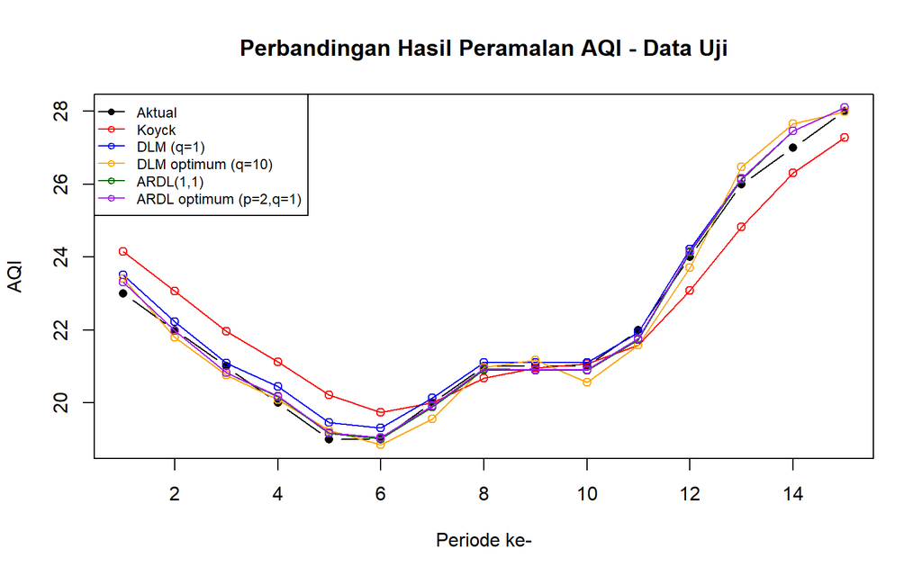

```r
waktu <- 1:nrow(test)

plot(waktu, test$Yt, type = "b", col = "black", pch = 16,
     ylim = range(c(test$Yt, fore.koyck$forecasts, fore.dlm$forecasts,
                     fore.dlm2$forecasts, fore.ardl$forecasts, fore.ardl.opt$forecasts)),
     xlab = "Periode ke-", ylab = "AQI",
     main = "Perbandingan Hasil Peramalan AQI - Data Uji")

lines(waktu, fore.koyck$forecasts, col = "red");     points(waktu, fore.koyck$forecasts, col = "red")
lines(waktu, fore.dlm$forecasts, col = "blue");      points(waktu, fore.dlm$forecasts, col = "blue")
lines(waktu, fore.dlm2$forecasts, col = "orange");   points(waktu, fore.dlm2$forecasts, col = "orange")
lines(waktu, fore.ardl$forecasts, col = "darkgreen");points(waktu, fore.ardl$forecasts, col = "darkgreen")
lines(waktu, fore.ardl.opt$forecasts, col = "purple");points(waktu, fore.ardl.opt$forecasts, col = "purple")

legend("topleft",
       c("Aktual", "Koyck", "DLM (q=1)", "DLM optimum (q=10)",
         "ARDL(1,1)", "ARDL optimum (p=2,q=1)"),
       lty = 1, pch = c(16, rep(1,5)),
       col = c("black", "red", "blue", "orange", "darkgreen", "purple"),
       cex = 0.75)
```

Dari grafik terlihat bahwa seluruh model peramalan mampu mengikuti pola naik-turun AQI aktual dengan cukup baik. Model **ARDL** (garis hijau tua dan ungu) tampak paling mendekati data aktual secara konsisten, sejalan dengan nilai MAPE-nya yang paling kecil.

# 10 Kesimpulan

1. Peubah **O3 (Ozon)** dipilih sebagai peubah independen ($X$) karena memiliki korelasi tertinggi terhadap AQI ($r\approx0.97$).
2. Ketiga metode (Koyck, DLM, ARDL) berhasil diterapkan, dengan lag/orde optimum sebagai berikut:
   - Koyck: model geometric lag (order tetap 1).
   - DLM: lag optimum $q=10$ berdasarkan AIC.
   - ARDL: orde optimum $(p,q)=(2,1)$ berdasarkan AIC.
3. Berdasarkan uji asumsi klasik (autokorelasi, heteroskedastisitas, dan normalitas), **model ARDL(1,1)** memberikan hasil paling konsisten: tidak ada autokorelasi (DW test) dan residual berdistribusi normal (Shapiro-Wilk), meskipun masih terindikasi heteroskedastisitas ringan.
4. Berdasarkan metrik akurasi **MAPE data uji**, seluruh model memiliki performa peramalan yang sangat baik (MAPE < 5%), dengan **model ARDL optimum (p=2, q=1)** memberikan nilai MAPE terkecil, sehingga dipilih sebagai model terbaik untuk meramalkan AQI Kota New Delhi berdasarkan konsentrasi O3.
5. Sebagai catatan, keterbatasan heteroskedastisitas pada beberapa model dapat diatasi lebih lanjut dengan pendekatan robust standard error atau transformasi peubah pada penelitian selanjutnya.